# Grocery Sales 2018

7/14/2019

## Exploratory Data Analysis

Data yang akan dianalisa dalam tugas LBB kali ini diambil dari kaggle, yakni Total Sales 2018 dari Grocery Shop.

- Pertama - tama, lakukan input dan pengecekan struktur data:

```
## 'data.frame':    23180 obs. of  16 variables:
##  $ Date      : Factor w/ 12 levels "01.01.2018","01.02.2018",..: 1 1 1 1 1 1 1 1 1 1 ...
##  $ PKod      : int  5307 5986 399 2246 2247 1305 1142 17316 3818 1143 ...
##  $ Pgroup    : Factor w/ 36 levels "ART._HYGIENIC",..: 6 6 12 12 12 12 12 18 12 12 ...
##  $ Pname     : Factor w/ 5134 levels " PATYCZKI BELLA 200",..: 1 8 18 19 20 21 23 24 25 27 ...
##  $ Pquantity : Factor w/ 1208 levels "0,03","0,04",..: 139 139 871 871 871 972 871 1033 1033 871 ...
##  $ pce_zn    : Factor w/ 1536 levels " ","0,01","0,02",..: 176 934 779 779 779 779 779 779 779 779 ...
##  $ pwa_zn    : Factor w/ 5783 levels "0,01","0,04",..: 168 2789 256 256 256 823 256 1258 1258 256 ...
##  $ pce_sn    : Factor w/ 1573 levels "0,1","0,16","0,2",..: 685 1249 1021 1021 713 1021 1021 1021 1021 1021 ...
##  $ pwa_sn    : Factor w/ 5803 levels "0,1","0,19","0,2",..: 1797 4192 1105 1105 404 1617 1105 2114 2114 1105 ...
##  $ pce_sb    : Factor w/ 1583 levels "0,12","0,2","0,25",..: 698 1380 1029 1029 1029 1029 1029 1029 1029 1029 ...
##  $ pwa_sb    : Factor w/ 6020 levels "0,12","0,2","0,24",..: 1861 4795 1160 1160 425 1736 1160 2273 2273 1160 ...
##  $ pudzsb    : Factor w/ 181 levels "0","0,01","0,02",..: 1 2 3 3 2 3 3 4 4 3 ...
##  $ pmarza    : Factor w/ 3998 levels "-0,04","-0,07",..: 2251 3318 2054 2054 3618 2054 2054 2054 2054 2054 ...
##  $ pmarzajedn: Factor w/ 934 levels "-0,01","-0,02",..: 295 487 327 327 232 327 327 327 327 327 ...
##  $ pkwmarza  : Factor w/ 3775 levels "-0,01","-0,02",..: 336 1451 2539 2539 324 2887 2539 3146 3146 2539 ...
##  $ pudzmarza : Factor w/ 191 levels "-0,01","-0,02",..: 21 23 25 25 21 26 25 27 27 25 ...
```

## Data Adjustment

Berdasarkan hasil pengecekan data, didapatkan bahwa banyak Field/Variabel yang tidak memiliki tipe yang sesuai ataupun kontennya kurang tepat, yakni:

- Date, variabel ini memiliki konten seperti tanggal, tapi ternyata merupakan bulan di tahun 2018.
- Pname, variabel ini perlu diubah menjadi Character karena sifatnya unik
- Pquantity, yakni Product quantity, perlu diubah menjadi numeric dan mengganti ‘,’ dengan ‘.’
- pce_zn, yakni Net price of purchase, perlu diubah menjadi numeric dan mengganti ‘,’ dengan ‘.’
- pwa_zn, yakni Net value of purchase (quantity*net purchase price), perlu diubah menjadi numeric dan mengganti ‘,’ dengan ‘.’
- pce_sn, yakni Net price of sale, perlu diubah menjadi numeric dan mengganti ‘,’ dengan ‘.’
- pwa_sn, yakni Net value of sale (quantity*net price of sale), perlu diubah menjadi numeric dan mengganti ‘,’ dengan ‘.’
- pce_sb, yakni Gross price of sale, perlu diubah menjadi numeric dan mengganti ‘,’ dengan ‘.’
- pwa_sb, yakni Gross value of sale (quantity*gross sale price), perlu diubah menjadi numeric dan mengganti ‘,’ dengan ‘.’
- pudzsb, yakni share in sales [%], perlu diubah menjadi numeric dan mengganti ‘,’ dengan ‘.’
- pmarza, yakni percent of margin [%], perlu diubah menjadi numeric dan mengganti ‘,’ dengan ‘.’
- pmarzajedn, yakni unit (product) margin, perlu diubah menjadi numeric dan mengganti ‘,’ dengan ‘.’
- pkwmarza, yakni sell margin (margin*quantity of sold products) [%], perlu diubah menjadi numeric dan mengganti ‘,’ dengan ‘.’
- pudzmarza, yakni share in margin [%], perlu diubah menjadi numeric dan mengganti ‘,’ dengan ‘.’

## Hasil Adjustment

```
## 'data.frame':    23180 obs. of  16 variables:
##  $ Month     : Factor w/ 12 levels "Apr","Aug","Dec",..: 5 5 5 5 5 5 5 5 5 5 ...
##  $ PKod      : int  5307 5986 399 2246 2247 1305 1142 17316 3818 1143 ...
##  $ Pgroup    : Factor w/ 36 levels "ART._HYGIENIC",..: 6 6 12 12 12 12 12 18 12 12 ...
##  $ Pname     : Factor w/ 5134 levels " PATYCZKI BELLA 200",..: 1 8 18 19 20 21 23 24 25 27 ...
##  $ Pquantity : int  1 1 4 4 4 5 4 6 6 4 ...
##  $ pce_zn    : num  1.77 3.2 2.68 2.68 2.68 2.68 2.68 2.68 2.68 2.68 ...
##  $ pwa_zn    : num  1.77 3.2 10.72 10.72 10.72 ...
##  $ pce_sn    : num  2.57 5.68 3.8 3.8 2.85 3.8 3.8 3.8 3.8 3.8 ...
##  $ pwa_sn    : num  2.57 5.68 15.2 15.2 11.4 19 15.2 22.8 22.8 15.2 ...
##  $ pce_sb    : num  2.78 6.99 3.99 3.99 3.99 3.99 3.99 3.99 3.99 3.99 ...
##  $ pwa_sb    : num  2.78 6.99 15.96 15.96 11.98 ...
##  $ pudzsb    : num  0 0.01 0.02 0.02 0.01 0.02 0.02 0.03 0.03 0.02 ...
##  $ pmarza    : num  31.13 43.66 29.47 29.47 5.96 ...
##  $ pmarzajedn: num  0.8 2.48 1.12 1.12 0.17 1.12 1.12 1.12 1.12 1.12 ...
##  $ pkwmarza  : num  0.8 2.48 4.48 4.48 0.68 5.6 4.48 6.72 6.72 4.48 ...
##  $ pudzmarza : num  0.01 0.03 0.05 0.05 0.01 0.06 0.05 0.07 0.07 0.05 ...
```

## Lihat Rangkuman Data

Langkah selanjutnya adalah melihat summary dari data untuk dapat insight isi data Sales 2018:

```
##      Month            PKod                     Pgroup
##  Aug    : 2144   Min.   :    2   SWEETS           : 2298
##  Jun    : 2047   1st Qu.: 3857   DAIRY_CHESSE     : 2297
##  Sep    : 2047   Median : 7928   CHEMISTRY        : 2152
##  May    : 2033   Mean   : 8325   DRINK_JUICE      : 2044
##  Jul    : 1965   3rd Qu.:11418   GENERAL_FOOD     : 1956
##  Mar    : 1927   Max.   :19952   ICE_CREAMS_FROZEN: 1334
##  (Other):11017                   (Other)          :11099
##                   Pname         Pquantity           pce_zn
##  SUROWKA KUBEK       :   33   Min.   :   0.00   Min.   :  0.010
##  RAJSTOPY 15 DEN INEZ:   25   1st Qu.:   2.00   1st Qu.:  1.295
##  ZAPALKI             :   25   Median :   4.00   Median :  2.180
##  CUKIER BIALY 1KG    :   23   Mean   :  15.94   Mean   :  3.542
##  SER FAVITA 270G     :   21   3rd Qu.:  11.00   3rd Qu.:  3.700
##  CLIN ZAPAS 500 ML   :   20   Max.   :2735.00   Max.   :500.000
##  (Other)             :23033                     NA's   :1
##      pwa_zn             pce_sn            pwa_sn            pce_sb
##  Min.   :   0.010   Min.   :  0.100   Min.   :   0.10   Min.   :  0.120
##  1st Qu.:   4.040   1st Qu.:  1.840   1st Qu.:   5.70   1st Qu.:  1.990
##  Median :   9.055   Median :  3.060   Median :  12.85   Median :  3.470
##  Mean   :  36.778   Mean   :  4.652   Mean   :  46.15   Mean   :  5.311
##  3rd Qu.:  21.500   3rd Qu.:  4.870   3rd Qu.:  29.88   3rd Qu.:  5.500
##  Max.   :3397.470   Max.   :500.000   Max.   :3923.52   Max.   :615.000
##
##      pwa_sb            pudzsb            pmarza          pmarzajedn
##  Min.   :   0.12   Min.   :0.00000   Min.   :-228.99   Min.   :-13.080
##  1st Qu.:   6.52   1st Qu.:0.01000   1st Qu.:  23.30   1st Qu.:  0.510
##  Median :  14.44   Median :0.01000   Median :  28.46   Median :  0.800
##  Mean   :  52.98   Mean   :0.05092   Mean   :  27.39   Mean   :  1.111
##  3rd Qu.:  33.98   3rd Qu.:0.03000   3rd Qu.:  32.95   3rd Qu.:  1.280
##  Max.   :4814.55   Max.   :4.35000   Max.   :  99.91   Max.   : 27.660
##
##     pkwmarza         pudzmarza
##  Min.   :-712.85   Min.   :-3.18000
##  1st Qu.:   1.54   1st Qu.: 0.01000
##  Median :   3.48   Median : 0.02000
##  Mean   :   9.37   Mean   : 0.05419
##  3rd Qu.:   8.12   3rd Qu.: 0.05000
##  Max.   : 710.94   Max.   : 4.33000
##
```

## Head Data

| Month | PKod | Pgroup | Pname | Pquantity | pce_zn | pwa_zn | pce_sn | pwa_sn | pce_sb | pwa_sb | pudzsb | pmarza | pmarzajedn | pkwmarza | pudzmarza |
| --- | --- | --- | --- | --- | --- | --- | --- | --- | --- | --- | --- | --- | --- | --- | --- |
| Jan | 5307 | CHEMISTRY | PATYCZKI BELLA 200 | 1 | 1.77 | 1.77 | 2.57 | 2.57 | 2.78 | 2.78 | 0.00 | 31.13 | 0.80 | 0.80 | 0.01 |
| Jan | 5986 | CHEMISTRY | ACE 1 L | 1 | 3.20 | 3.20 | 5.68 | 5.68 | 6.99 | 6.99 | 0.01 | 43.66 | 2.48 | 2.48 | 0.03 |
| Jan | 399 | DAIRY_CHESSE | ALMETTE CZOSNEK NIEDZWIEDZI 150GR | 4 | 2.68 | 10.72 | 3.80 | 15.20 | 3.99 | 15.96 | 0.02 | 29.47 | 1.12 | 4.48 | 0.05 |
| Jan | 2246 | DAIRY_CHESSE | ALMETTE JOGURTOWY 150G HOCHLAND | 4 | 2.68 | 10.72 | 3.80 | 15.20 | 3.99 | 15.96 | 0.02 | 29.47 | 1.12 | 4.48 | 0.05 |
| Jan | 2247 | DAIRY_CHESSE | ALMETTE OGOREK/ZIOLA 150G | 4 | 2.68 | 10.72 | 2.85 | 11.40 | 3.99 | 11.98 | 0.01 | 5.96 | 0.17 | 0.68 | 0.01 |
| Jan | 1305 | DAIRY_CHESSE | ALMETTE SER POMIDOR 150 G | 5 | 2.68 | 13.40 | 3.80 | 19.00 | 3.99 | 19.95 | 0.02 | 29.47 | 1.12 | 5.60 | 0.06 |

## Tail Data

|  | Month | PKod | Pgroup | Pname | Pquantity | pce_zn | pwa_zn | pce_sn | pwa_sn | pce_sb | pwa_sb | pudzsb | pmarza | pmarzajedn | pkwmarza | pudzmarza |
| --- | --- | --- | --- | --- | --- | --- | --- | --- | --- | --- | --- | --- | --- | --- | --- | --- |
| 23175 | Dec | 9252 | ICE_CREAMS_FROZEN | ZUPA WIOSENNA 450G NORDIS | 5 | 3.47 | 17.35 | 4.75 | 23.75 | 4.99 | 24.95 | 0.03 | 26.95 | 1.28 | 6.40 | 0.04 |
| 23176 | Dec | 6590 | GENERAL | ZURAWINA 80 G HELIO | 6 | 1.85 | 11.10 | 3.05 | 18.30 | 3.29 | 19.74 | 0.02 | 39.34 | 1.20 | 7.20 | 0.04 |
| 23177 | Dec | 19580 | GENERAL_FOOD | ZURAWINA S?OIK 230 G | 2 | 4.51 | 9.02 | 6.19 | 12.38 | 6.69 | 13.38 | 0.01 | 27.14 | 1.68 | 3.36 | 0.02 |
| 23178 | Dec | 10274 | SWEETS | ZURAWINA W CZEKOLADZIE 70 G EURO | 2 | 1.83 | 3.66 | 2.62 | 5.24 | 3.22 | 6.44 | 0.01 | 30.15 | 0.79 | 1.58 | 0.01 |
| 23179 | Dec | 1775 | GENERAL | ZUREK BUTELKA 0_5 L | 2 | 1.31 | 2.62 | 1.48 | 2.96 | 1.60 | 3.20 | 0.00 | 11.49 | 0.17 | 0.34 | 0.00 |
| 23180 | Dec | 16876 | GENERAL_FOOD | ZUREK KRAKUS BUT 300G | 1 | 3.20 | 3.20 | 3.85 | 3.85 | 4.16 | 4.16 | 0.00 | 16.88 | 0.65 | 0.65 | 0.00 |

## Data Insight #1

- Jumlah Penjualan terbanyak terdapat di bulan Agustus (2,144)
- SWEETS merupakan group produk dengan jumlah penjualan terbanyak
- Dari jumlah produk terjual, terlihat adanya anomali dimana nilai 3rd Qu: 11 namun Max. nya 2,735, menandakan rentangnya jauh
- Dan ditemukan juga produk dengan Pquantity = 0 namun memiliki value:

  |  | Pquantity | pce_zn | pwa_zn | pce_sn | pwa_sn | pce_sb | pwa_sb | pudzsb | pmarza | pmarzajedn | pkwmarza | pudzmarza |
  | --- | --- | --- | --- | --- | --- | --- | --- | --- | --- | --- | --- | --- |
  | 170 | 0 | 13.95 | 12.69 | 23.13 | 21.05 | 25.00 | 22.75 | 0.03 | 39.71 | 9.19 | 8.36 | 0.09 |
  | 173 | 0 | 12.00 | 7.68 | 16.25 | 10.40 | 20.00 | 12.80 | 0.01 | 26.15 | 4.25 | 2.72 | 0.03 |
  | 180 | 0 | 9.33 | 1.68 | 13.83 | 2.49 | 17.00 | 3.06 | 0.00 | 32.53 | 4.50 | 0.81 | 0.01 |
  | 199 | 0 | 14.20 | 4.97 | 20.29 | 7.10 | 24.97 | 8.74 | 0.01 | 30.00 | 6.09 | 2.13 | 0.02 |
  | 200 | 0 | 16.90 | 14.11 | 23.58 | 19.69 | 28.98 | 24.20 | 0.03 | 28.34 | 6.68 | 5.58 | 0.06 |
  | 202 | 0 | 10.00 | 4.90 | 14.29 | 7.00 | 17.55 | 8.60 | 0.01 | 30.00 | 4.29 | 2.10 | 0.02 |
  | 203 | 0 | 17.00 | 3.23 | 23.58 | 4.48 | 29.00 | 5.51 | 0.01 | 27.90 | 6.58 | 1.25 | 0.01 |
  | 205 | 0 | 14.65 | 11.50 | 20.65 | 16.21 | 25.39 | 19.93 | 0.02 | 29.06 | 6.00 | 4.71 | 0.05 |
  | 206 | 0 | 5.59 | 5.25 | 7.99 | 7.50 | 8.39 | 7.88 | 0.01 | 30.00 | 2.40 | 2.25 | 0.02 |
  | 297 | 0 | 23.50 | 22.44 | 23.57 | 22.51 | 24.76 | 23.65 | 0.03 | 0.31 | 0.07 | 0.07 | 0.00 |
  | 298 | 0 | 13.20 | 7.92 | 18.08 | 10.85 | 18.98 | 11.39 | 0.01 | 27.00 | 4.88 | 2.93 | 0.03 |
  | 301 | 0 | 16.62 | 15.46 | 21.31 | 19.82 | 22.38 | 20.81 | 0.02 | 22.00 | 4.69 | 4.36 | 0.05 |
  | 323 | 0 | 14.63 | 4.90 | 18.09 | 6.06 | 18.99 | 6.36 | 0.01 | 19.14 | 3.46 | 1.16 | 0.01 |
  | 493 | 0 | 16.00 | 5.44 | 20.94 | 7.12 | 22.00 | 7.48 | 0.01 | 23.60 | 4.94 | 1.68 | 0.02 |
  | 494 | 0 | 16.83 | 7.74 | 15.63 | 7.19 | 16.41 | 7.55 | 0.01 | -7.65 | -1.20 | -0.55 | -0.01 |
  | 523 | 0 | 8.84 | 3.80 | 5.51 | 2.37 | 5.79 | 2.49 | 0.00 | -60.34 | -3.33 | -1.43 | -0.01 |
  | 548 | 0 | 15.65 | 4.46 | 19.68 | 5.61 | 20.67 | 5.89 | 0.01 | 20.50 | 4.04 | 1.15 | 0.01 |
  | 549 | 0 | 19.68 | 3.74 | 24.58 | 4.67 | 25.79 | 4.90 | 0.01 | 19.91 | 4.89 | 0.93 | 0.01 |
  | 550 | 0 | 18.16 | 17.34 | 10.32 | 9.86 | 10.84 | 10.35 | 0.01 | -75.86 | -7.83 | -7.48 | -0.08 |
  | 551 | 0 | 23.24 | 3.95 | 28.59 | 4.86 | 30.00 | 5.10 | 0.01 | 18.72 | 5.35 | 0.91 | 0.01 |
  | 553 | 0 | 19.17 | 11.02 | 23.98 | 13.79 | 25.17 | 14.47 | 0.02 | 20.09 | 4.82 | 2.77 | 0.03 |
  | 557 | 0 | 19.75 | 0.79 | 24.50 | 0.98 | 25.75 | 1.03 | 0.00 | 19.39 | 4.75 | 0.19 | 0.00 |
  | 560 | 0 | 22.19 | 20.53 | 14.82 | 13.71 | 15.57 | 14.40 | 0.02 | -49.74 | -7.37 | -6.82 | -0.07 |
  | 561 | 0 | 19.18 | 12.56 | 21.85 | 14.31 | 22.93 | 15.02 | 0.02 | 12.23 | 2.67 | 1.75 | 0.02 |
  | 563 | 0 | 11.87 | 6.23 | 14.67 | 7.70 | 15.39 | 8.08 | 0.01 | 19.09 | 2.80 | 1.47 | 0.02 |
  | 615 | 0 | 10.44 | 4.07 | 7.15 | 2.79 | 7.51 | 2.93 | 0.00 | -45.88 | -3.28 | -1.28 | -0.01 |
  | 619 | 0 | 21.01 | 8.72 | 26.24 | 10.89 | 27.57 | 11.44 | 0.01 | 19.93 | 5.23 | 2.17 | 0.02 |
  | 636 | 0 | 2.11 | 1.99 | 2.08 | 1.97 | 2.19 | 2.07 | 0.00 | -1.02 | -0.02 | -0.02 | 0.00 |
  | 642 | 0 | 5.11 | 1.38 | 3.26 | 0.88 | 3.52 | 0.95 | 0.00 | -56.82 | -1.85 | -0.50 | -0.01 |
  | 645 | 0 | 14.58 | 5.83 | 18.23 | 7.29 | 22.43 | 8.97 | 0.01 | 20.03 | 3.65 | 1.46 | 0.02 |

  [output cut: 485 more lines]

  - Untuk selanjutnya akan dihilangkan karena merupakan penyimpangan

## Data Insight #2

  |  | Pname | pwa_zn | pwa_sn | pmarza |
  | --- | --- | --- | --- | --- |
  | 17343 | US?UGA MARKETINGOWA PO 3001936598 | 500 | 500 | 0 |

- Ternyata produk dengan nilai penjualan tertinggi tidak menjamin mendapatkan margin besar
- Lihat nama produk dengan margin penjualan terbesar dan terkecil

  |  | Pname | Pgroup | pwa_zn | pwa_sn | pmarza |
  | --- | --- | --- | --- | --- | --- |
  | 14118 | KT POMIDOR POLSKI POLNY | VEGETABLES | 1298.23 | 585.38 | -121.78 |
  | 14571 | NAP SPIR ZOLADKOWA GORZKA 36% 0_2L | VODKA_ALCOHOL | 0.04 | 42.24 | 99.91 |
  | 16652 | NAP SPIR ZOLADKOWA GORZKA 36% 0_2L | VODKA_ALCOHOL | 0.05 | 52.80 | 99.91 |
  | 18574 | NAP SPIR ZOLADKOWA GORZKA 36% 0_2L | VODKA_ALCOHOL | 0.08 | 84.48 | 99.91 |

## Data Insight #3

- Lihat Kategori Produk dengan Net value of sale lebih besar dari rataan

  | Pgroup | pwa_sn |
  | --- | --- |
  | BEER | 251 |
  | BREAD | 343 |
  | CANNED_PATE | 45 |
  | CHEMISTRY | 55 |
  | CHEWING_GUM_LOLIPOPS | 16 |
  | CHIPS_FLAKES | 47 |
  | CIGARETTES | 599 |
  | COFFEE TEA | 38 |
  | COOKIES_BULK | 26 |
  | DAIRY_CHESSE | 431 |
  | DISHES_FOR_CHILDREN | 3 |
  | DRINK_JUICE | 301 |
  | EGGS | 24 |
  | FISH | 18 |
  | GENERAL | 20 |
  | GENERAL_FOOD | 166 |
  | GROATS_RICE_PASTA | 37 |
  | ICE_CREAMS_FROZEN | 259 |
  | KETCH_CONCETRATE_MUSTARD_MAJO_HORSERADISH | 140 |
  | MEAT | 53 |
  | OCCASIONAL | 19 |
  | OILS | 62 |
  | PHONES_ADJUSTMENTS | 26 |
  | SOCKS_THIGHTS | 3 |
  | SPICES | 4 |
  | SWEETS | 187 |
  | TABLETS | 8 |
  | VEGETABLES | 363 |
  | VODKA_ALCOHOL | 348 |
  | WINE_ALCOHOL 18% | 25 |

- Cigarette merupakan kategori produk yang terbanyak terjual dengan Net value of sale > rataan
- Lihat Penjualan pada masing - masing Bulan di 2018

  | Month | pwa_sn |
  | --- | --- |
  | Jan | 76202.17 |
  | Feb | 70433.30 |
  | Mar | 87580.34 |
  | Apr | 81190.23 |
  | May | 97025.12 |
  | Jun | 95752.04 |
  | Jul | 102783.84 |
  | Aug | 105167.34 |
  | Sep | 97012.57 |
  | Oct | 84789.84 |
  | Nov | 82843.04 |
  | Dec | 84744.91 |

- Penjualan terbesar terdapat di Bulan Jul-Aug (kemungkinan karena Summer)

## Data Insight #4

- Cari Produk dengan Rataan Sell Margin (Margin*Jumlah Produk Terjual) Terbesar

  | Pgroup | pkwmarza |
  | --- | --- |
  | ART._HYGIENIC | 3.215247 |
  | ARTICLE_OF_HOUSEHOLD | 0.812500 |
  | BEER | 24.956567 |
  | BREAD | 48.017704 |
  | CANNED_PATE | 7.354373 |
  | CHEMISTRY | 3.401255 |
  | CHEWING_GUM_LOLIPOPS | 5.359458 |
  | CHIPS_FLAKES | 6.011552 |
  | CIGARETTES | 15.014353 |
  | COFFEE TEA | 4.166245 |
  | COOKIES_BULK | 9.954091 |
  | DAIRY_CHESSE | 9.678556 |
  | DISHES_FOR_CHILDREN | 6.254865 |
  | DRINK_JUICE | 8.626815 |
  | EGGS | 48.410833 |
  | FISH | 4.761424 |
  | GENERAL | 3.103189 |
  | GENERAL_FOOD | 5.073551 |
  | GROATS_RICE_PASTA | 5.195174 |
  | ICE_CREAMS_FROZEN | 8.533105 |
  | KETCH_CONCETRATE_MUSTARD_MAJO_HORSERADISH | 7.923227 |
  | LUNCH DINING DISHES | 3.384167 |
  | MEAT | 5.628578 |
  | MILK | 4.380000 |
  | OCCASIONAL | 7.095686 |
  | OILS | 10.331000 |
  | PACKAGES | 0.892500 |
  | PET’S FOOD | 3.524203 |
  | PHONES_ADJUSTMENTS | 33.844000 |
  | SOCKS_THIGHTS | 3.096788 |
  | SPICES | 2.127664 |
  | SWEETS | 6.191692 |
  | TABLETS | 3.613849 |
  | VEGETABLES | 24.852644 |
  | VODKA_ALCOHOL | 27.972983 |
  | WINE_ALCOHOL 18% | 5.506214 |

- EGG merupakan Kategori Produk dengan Rataan Sell Margin terbesar

## Data Insight #5

- Cari Korelasi Antara Sell Margin dengan Tingkat Net Value Salesnya

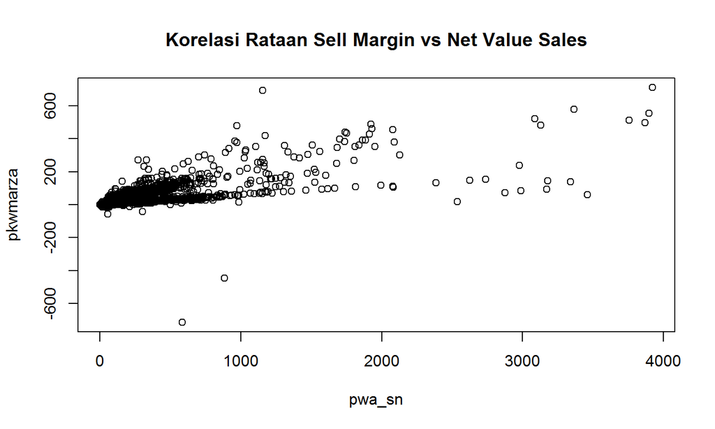

- Semakin tinggi Net Value Sales maka Sell Margin juga makin tinggi